# Report Exercise: Digital Soil Mapping

Salome Hayler

22.12.2025

# 1. Introduction

Soil conditions vary strongly from place to place and influence land use and infrastructure planning. An important soil property is waterlogging, which affects soil stability and drainage, among other things. This exercise uses the digital soil mapping workflow from the tutorial “Digital Soil Mapping - Predicting soil properties from spatial data” by Pascal Schneider, Benjamin Stocker, Madlene Nussbaum (2023) (available at: https://geco-bern.github.io/tutorial_digital_soil_mapping/) is applied to the binary categorical variable waterlog.100. This variable indicates whether the soil is waterlogged at a depth of 100 cm throughout the canton of Bern (TRUE or FALSE). The analysis is based on soil data as point observations of soil properties from field sampling sites in combination with a large set of spatially continuous environmental covariates. First, a simple random forest model is trained using all predictors and evaluated using a test dataset. Next, variable selection and hyperparameter optimization are applied using cross-validation to improve model performance. Finally, probabilistic predictions are used to investigate how different classification thresholds affect decision-making in different application contexts.

# 2. Re-implemention of the digital soil mapping workflow for waterlog.100

The data required for this exercise was downloaded from the tutorial “tutorial_digital_soil_mapping,” preprocessed according to the tutorial instructions, and then saved in the data folder. The R Markdown file is linked to this folder, while the complete code for preprocessing the raw data (see folder “data_raw”) is not displayed in the rendered document.

```r
# required packages
packages <- c(
  "dplyr",
  "tidyr",
  "readr",
  "tibble",
  "terra",
  "sf",
  "tidyterra",
  "ggplot2",
  "lattice",
  "ranger",
  "Boruta",
  "caret",
  "recipes",
  "pROC",
  "knitr",
  "rmarkdown",
  "here"
)
```

## 2.1 Simple model for waterlog.100

waterlog.100 is a binary categorical variable that indicates whether the soil is waterlogged at a depth of 100 cm. In this workflow, it is coded as 0 (not waterlogged) and 1 (waterlogged).

### 2.1.1 Random forest for waterlog.100

```r
# load dataframe
df_full_soil <- readRDS(here::here("data/df_full.rds"))

df_full_soil |>
  knitr::kable()
```

[output not shown]

```r
# specify target: binary waterlog.100
target_wl <- "waterlog.100"
```

```r
# make as factor
df_full_soil[[target_wl]] <- factor(df_full_soil[[target_wl]])
```

```r
# specify predictors_all: Remove soil sampling and observational data
predictors_all <- names(df_full_soil)[14:ncol(df_full_soil)]

cat("The target is:", target_wl,
    "\nThe predictors_all are:", paste0(predictors_all[1:8], sep = ", "), "...")
```

```
## The target is: waterlog.100
## The predictors_all are: be_gwn25_hdist,  be_gwn25_vdist,  cindx10_25,  cindx50_25,  geo500h1id,  geo500h3id,  lgm,  lsf,  ...
```

```r
# split dataset into training and testing sets
df_train_wl <- df_full_soil |> dplyr::filter(dataset == "calibration")
df_test_wl  <- df_full_soil |> dplyr::filter(dataset == "validation")
```

```r
# encode target variable as factor
df_train_wl[[target_wl]] <- factor(df_train_wl[[target_wl]])
df_test_wl[[target_wl]]  <- factor(df_test_wl[[target_wl]])
```

```r
# filter out any NA to avoid error when running a random forest
df_train_wl <- df_train_wl |> tidyr::drop_na()
df_test_wl  <- df_test_wl   |> tidyr::drop_na()
```

```r
# a little bit of verbose output
n_tot <- nrow(df_train_wl) + nrow(df_test_wl)

perc_cal <- (nrow(df_train_wl) / n_tot) |> round(2) * 100
perc_val <- (nrow(df_test_wl)  / n_tot) |> round(2) * 100

cat("For model training, we have a calibration / validation split of: ",
    perc_cal, "/", perc_val, "%")
```

```
## For model training, we have a calibration / validation split of:  75 / 25 %
```

```r
# ranger() crashes when using tibbles, so we are using the
# base R notation to enter the data
rf_basic_wl <- ranger::ranger(
  y = df_train_wl[, target_wl],       # target variable
  x = df_train_wl[, predictors_all],  # Predictor variables
  seed = 42,                          # Specify seed for randomization to reproduce the same model again
  num.threads = parallel::detectCores() - 1) # Use all but one CPU core for quick model training
```

```r
# print a summary of the fitted model
print(rf_basic_wl)
```

```
## Ranger result
##
## Call:
##  ranger::ranger(y = df_train_wl[, target_wl], x = df_train_wl[,      predictors_all], seed = 42, num.threads = parallel::detectCores() -      1)
##
## Type:                             Classification
## Number of trees:                  500
## Sample size:                      605
## Number of independent variables:  91
## Mtry:                             9
## Target node size:                 1
## Variable importance mode:         none
## Splitrule:                        gini
## OOB prediction error:             21.49 %
```

The basic random forest model for waterlog.100 used 91 predictor variables and the gini splitrule. The out-of-bag prediction error (OOB) is 21.49%, which provides an estimate of how often the model makes incorrect predictions for new data. This figure means that the model misclassified approximately 1 in 5 samples during training.

### 2.1.2 Model performance on the test dataset

In the following, the model is evaluated using appropriate metrics, including the visualization of a confusion matrix, from AGDS Book Chapter 9.4.1.2. (https://geco-bern.github.io/agds_book/regression_classification.html#metrics-for-classification) based on the test dataset.

```r
# predictions on the test dataset (basic model, direct class predictions 0/1)
pred_test_basic <- predict(
  rf_basic_wl,                         # basic RF model
  data = df_test_wl[, predictors_all]  # predictors from the test set (all covariates)
)

# extract predicted classes
pred_class_basic <- pred_test_basic$predictions

# extract true observed classes from the test dataset
obs_class_basic <- df_test_wl[[target_wl]]
```

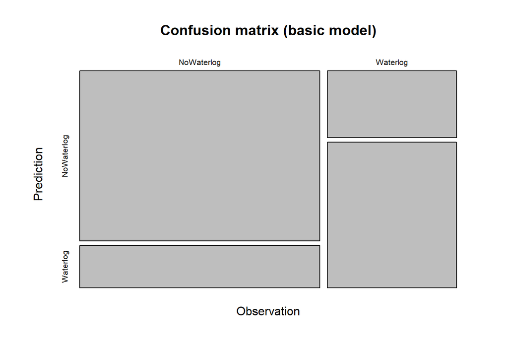

Figure 1: Confusion Matrix for the simple model.

```r
# create confusion matrix
cm_table_basic <- table(
  Observation = factor(obs_class_basic, levels = c(0, 1), labels = c("NoWaterlog", "Waterlog")),
  Prediction  = factor(pred_class_basic, levels = c(0, 1), labels = c("NoWaterlog", "Waterlog"))
)

mosaicplot(cm_table_basic,
  main = "Confusion matrix (basic model)"
)
```

```r
#    0  1
# 0 TN  FP
# 1 FN  TP
```

```r
# extract True Positives (TP), True Negatives (TN), False Positives (FP), and False Negatives (FN) from the confusion matrix
TP <- cm_table_basic["Waterlog", "Waterlog"]
TN <- cm_table_basic["NoWaterlog", "NoWaterlog"]
FP <- cm_table_basic["NoWaterlog", "Waterlog"]
FN <- cm_table_basic["Waterlog", "NoWaterlog"]

# accuracy
accuracy_basic <- (TP + TN) / (TP + TN + FP + FN)

# precision
precision_basic <- TP / (TP + FP)

# true positive rate (=sensitivity)
tpr_basic <- TP / (TP + FN)

# false positive rate
fpr_basic <- FP / (FP + TN)

# calculated metrics in table format
metrics_basic <- data.frame(
  Metric = c("Accuracy", "Precision", "True positive rate", "False positive rate"),
  Value = c(round(accuracy_basic, 6),
            round(precision_basic, 6),
            round(tpr_basic, 6),
            round(fpr_basic, 6))
)

metrics_basic
```

```
##                Metric    Value
## 1            Accuracy 0.760000
## 2           Precision 0.648649
## 3  True positive rate 0.685714
## 4 False positive rate 0.200000
```

The basic model has an **accuracy** (total proportion of correct predictions) of **76%**, a **precision** (proportion of predicted waterlogged soils that are actually waterlogged) of **65%**, a **true positive rate** (proportion of actually waterlogged soils that were correctly predicted) of **69%**, and a **false positive rate** (proportion of non-waterlogged soils that were incorrectly predicted as waterlogged) of **20%**. This means that the model correctly predicts most cases, but still overlooks some waterlogged soils. The same information can be seen in Figure 1 (confusion matrix above), where the largest block represents the correctly predicted non-waterlogged cases (TRUE negatives).

```r
# absolute frequencies of each class
table(df_test_wl[[target_wl]])
```

```
##
##   0   1
## 130  70
```

```r
# percentage of each class
prop.table(table(df_test_wl[[target_wl]]))
```

```
##
##    0    1
## 0.65 0.35
```

The absolute frequencies of the observed classes in the test data are 70 for waterlogged (class 1) and 130 for non-waterlogged (class 0) soils. In percentage terms, this corresponds to 35% water-saturated and 65% non-water-saturated soils in the dataset. This means that the data is not balanced, as there are more non-water-saturated samples (130) than water-saturated samples (70). A balanced dataset would have approximately the same number of samples in each class. This means that accuracy alone can be misleading, as the model could be largely correct by predicting the majority class (i.e., non-waterlogged soils). Therefore, it is important to also consider precision, the true positive rate, and the false positive rate to see how well the model predicts waterlogged soils.

Overall, the baseline model performs better than chance and finds most of the actual waterlogged soils, but it still predicts some areas as waterlogged that are not. Since the precision is lower than the true positive rate, this means that the model predicts waterlogged soils slightly too often compared to the actual cases.

## 2.2 Variable selection

This section follows the tutorial to simplify the model. First, the variable significance is checked using the permutation method. Then, Boruta is used to select the most important predictors. The model is retrained and tested to check its performance compared to the model with all variables. The OOB error is also considered to verify the model selection.

### 2.2.1 Variable importance

The variable importance is first calculated using the permutation method to determine which predictors contribute most to the model.

```r
# ranger() crashes when using tibbles, so we are using the
# base R notation to enter the data
rf_basic_wl_ <- ranger::ranger(
  y = df_train_wl[, target_wl],       # target variable
  x = df_train_wl[, predictors_all],  # Predictor variables
  importance   = "permutation",       # with variable importance
  seed = 42,                          # set seed for reproducibility of the same model again
  num.threads = parallel::detectCores() - 1) # use all but one CPU core for quick model training
```

```r
# extract the variable importance and create a long tibble
vi_rf_basic_wl <- rf_basic_wl_$variable.importance |>
  dplyr::bind_rows() |>
  tidyr::pivot_longer(cols = dplyr::everything(), names_to = "variable")
```

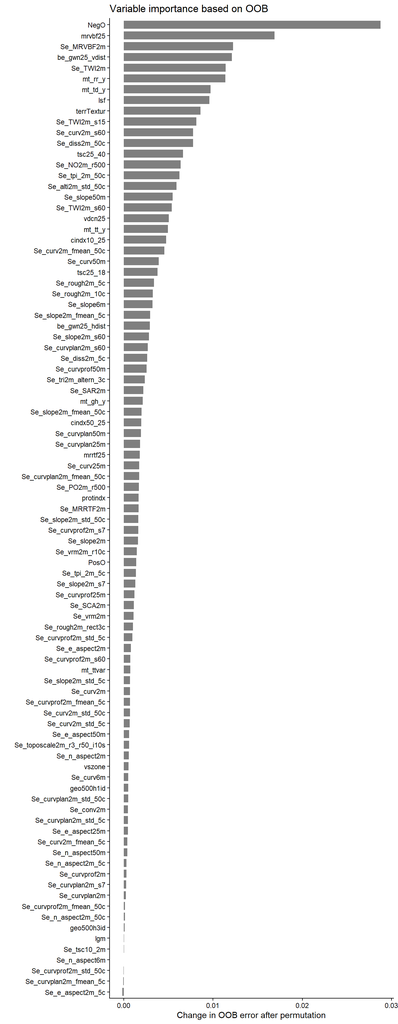

Figure 2: Variable importance based on OBB.

```r
# plot variable importance, ordered by decreasing value
gg_wl <- vi_rf_basic_wl |>
  ggplot2::ggplot(ggplot2::aes(x = reorder(variable, value), y = value)) +
  ggplot2::geom_bar(stat = "identity", fill = "grey50", width = 0.75) +
  ggplot2::labs(
    y = "Change in OOB error after permutation",
    x = "",
    title = "Variable importance based on OOB") +
  ggplot2::theme_classic() +
  ggplot2::coord_flip()
gg_wl # display plot
```

Figure 2 shows that NegO (Topographic negative openness) ist the most important variable, followed by mrvbf25 (Multi-resolution valley bottom flatness at 25m resolution), Se_MRVBF2m (Multi-resolution valley bottom flatness at 2 m resolution), be_gwn25_vdist (Horizontal distance to water body at 25m resolution), Se_TWI2m (Topographic wetness index at 2 m resolution), mt_rr_y (Mean annual temperature) etc… This means these variables contribute the most to the model’s predictions and explain the most variation in whether a soil is waterlogged or not (most important variables at predicting the target variable waterlog.100). (Explanations for the other variables here: https://geco-bern.github.io/tutorial_digital_soil_mapping/99-variables.html).

### 2.2.2 Boruta variable selection

In the following, Boruta is used as a variable selection method to identify the most important variables and remove predictors that do not significantly improve the model.

```r
# boruta variable selection
set.seed(42)

# run the algorithm
bor_wl <- Boruta::Boruta(
  y = df_train_wl[, target_wl],
  x = df_train_wl[, predictors_all],
  maxRuns = 50, # number of iterations, can be set lower for faster computation
  num.threads = parallel::detectCores()-1)
```

```r
# obtain results -> data frame with all variables, ordered by their importance
df_bor_wl <- Boruta::attStats(bor_wl) |>
  tibble::rownames_to_column() |>
  dplyr::arrange(dplyr::desc(meanImp))
```

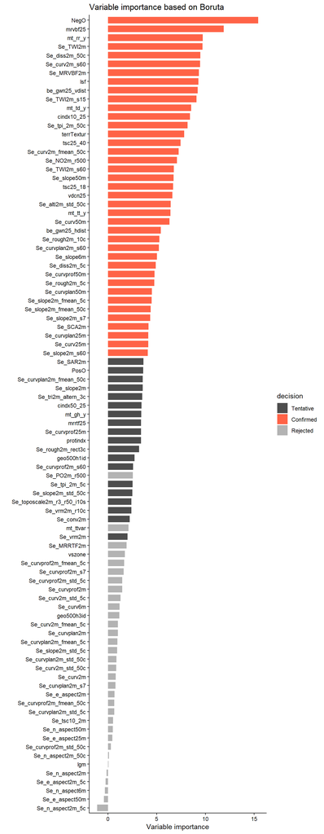

Figure 3: Boruta variable selection.

```r
# plot the importance result
ggplot2::ggplot(ggplot2::aes(x = reorder(rowname, meanImp),
                             y = meanImp,
                             fill = decision),
                data = df_bor_wl) +
  ggplot2::geom_bar(stat = "identity", width = 0.75) +
  ggplot2::scale_fill_manual(values = c("grey30", "tomato", "grey70")) +
  ggplot2::labs(
    y = "Variable importance",
    x = "",
    title = "Variable importance based on Boruta") +
  ggplot2::theme_classic() +
  ggplot2::coord_flip()
```

```r
# get retained important variables
predictors_selected_wl <- df_bor_wl |>
  dplyr::filter(decision == "Confirmed") |>
  dplyr::pull(rowname)

length(predictors_selected_wl)
```

```
## [1] 39
```

With the help of Boruta, 39 variables were selected from the original set of 91 predictors to predict the target variable “waterlog.100.” A description of the abbreviations in Figure 3 can be found under “https://geco-bern.github.io/tutorial_digital_soil_mapping/99-variables.html”.

```r
# retrain random forest model with the 39 selected predictors
rf_bor_wl <- ranger::ranger(
  y = df_train_wl[, target_wl],              # target variable
  x = df_train_wl[, predictors_selected_wl], # predictor variables
  seed = 42,                                 # set seed for reproducibility of the model
  num.threads = parallel::detectCores() - 1)
```

```r
# quick report and performance of retrained model object
print(rf_bor_wl)
```

```
## Ranger result
##
## Call:
##  ranger::ranger(y = df_train_wl[, target_wl], x = df_train_wl[,      predictors_selected_wl], seed = 42, num.threads = parallel::detectCores() -      1)
##
## Type:                             Classification
## Number of trees:                  500
## Sample size:                      605
## Number of independent variables:  39
## Mtry:                             6
## Target node size:                 1
## Variable importance mode:         none
## Splitrule:                        gini
## OOB prediction error:             20.00 %
```

The Boruta-based random forest model for waterlog.100 used 39 predictor variables. The out-of-bag error (OOB) is then 20.00%, which is slightly lower and thus better than the error of the basic model (which was 21.49%, see section 2.1.1).

### 2.2.3 Model performance on the test dataset

Now, the boruta model performance is tested on the test dataset (similar to what has been done in chapter 2.1.2 for the basic model).

```r
# predictions on the test dataset (retrained model, direct class predictions 0/1)
pred_test_bor <- predict(
  rf_bor_wl,                                  # retrained random forest model
  data = df_test_wl[, predictors_selected_wl] # predictors from the test set
)

# extract predicted classes
pred_class_bor <- pred_test_bor$predictions

# extract true observed classes from the test dataset ---
obs_class_bor <- df_test_wl[[target_wl]]

# create confusion matrix
cm_table_bor <- table(
  Observation = factor(obs_class_bor, levels = c(0, 1), labels = c("NoWaterlog", "Waterlog")),
  Prediction  = factor(pred_class_bor, levels = c(0, 1), labels = c("NoWaterlog", "Waterlog"))
)
```

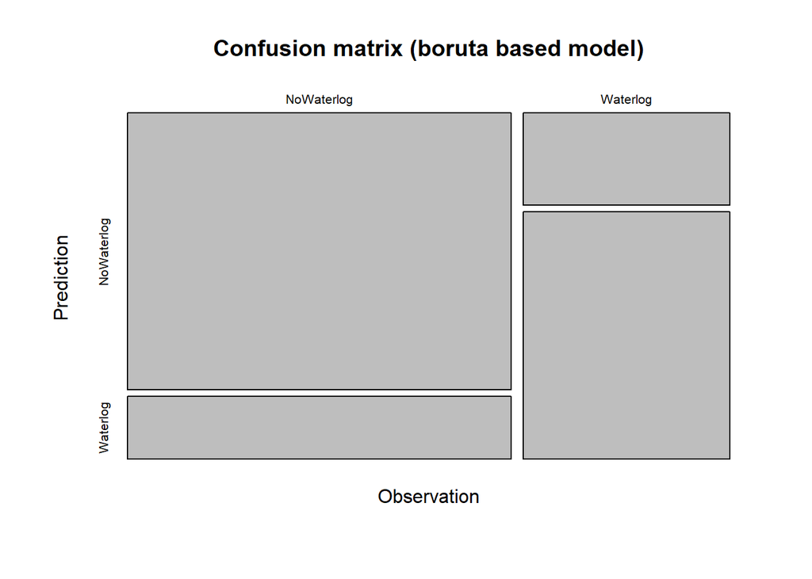

Figure 4: Confusion Matrix for Boruta variable selection.

```r
mosaicplot(cm_table_bor,
  main = "Confusion matrix (boruta based model)"
)
```

```r
#    0  1
# 0 TN  FP
# 1 FN  TP
```

```r
# extract TP, TN, FP, FN from the confusion matrix
TP <- cm_table_bor["Waterlog", "Waterlog"]
TN <- cm_table_bor["NoWaterlog", "NoWaterlog"]
FP <- cm_table_bor["NoWaterlog", "Waterlog"]
FN <- cm_table_bor["Waterlog", "NoWaterlog"]

# accuracy
accuracy_bor <- (TP + TN) / (TP + TN + FP + FN)

# precision
precision_bor <- TP / (TP + FP)

# true positive rate (=sensitivity)
tpr_bor <- TP / (TP + FN)

# false positive rate
fpr_bor <- FP / (FP + TN)

# calculated metrics in table format
metrics_bor <- data.frame(
  Metric = c("Accuracy", "Precision", "True positive rate", "False positive rate"),
  Value = c(round(accuracy_bor, 6),
            round(precision_bor, 6),
            round(tpr_bor, 6),
            round(fpr_bor, 6))
)

metrics_bor
```

```
##                Metric    Value
## 1            Accuracy 0.785000
## 2           Precision 0.680000
## 3  True positive rate 0.728571
## 4 False positive rate 0.184615
```

### 2.2.4 Comparison: Simple (basic) model vs. model with variable selection (boruta)

**Which model generalises better to unseen data?**

```r
# comparison of OBB prediction errors
rf_basic_wl$prediction.error
```

```
## [1] 0.214876
```

```r
rf_bor_wl$prediction.error
```

```
## [1] 0.2
```

**OBB comparison:** The out-of-bag error (OOB) for the baseline model is 0.214876 (~21.49%), while the Boruta-based model has an OOB error of 0.2 (20.00%). Since the Boruta model has a slightly lower OOB error, it would still be selected as the better model if the decision were based solely on the OOB error. However, the difference is very small, so both models perform quite similarly according to the OBB results.

# 3. Model optimization

To improve model performance, a 5-fold cross-validation was applied to tune the hyperparameters of the random forest model.

## 3.1 Hyperparameter tuning

```r
# define hyperparameter grid for tuning
pp <- recipes::recipe(
  stats::as.formula(
    paste(target_wl, "~", paste(predictors_selected_wl, collapse = "+"))),
                      data = df_train_wl)|>
  recipes::step_center(recipes::all_numeric(), -recipes::all_outcomes()) |>
  recipes::step_scale(recipes::all_numeric(), -recipes::all_outcomes())

set.seed(42)  # set seed for reproducibility

p <- floor(sqrt(length(predictors_selected_wl))) # estimate good mtry values from my data

tune_grid <- expand.grid(
  .mtry = c(4, p, 8),                   # try different mtry values
  .min.node.size = c(1,3,5,8,10,15,20), # try different min.node.size values
  .splitrule = "gini"                   # standard splitrule for classification
)
```

```r
# train a random forest with 5-fold cross validation
set.seed(42)  # set seed for reproducibility

mod_cv <- caret::train(
  pp,
  data = df_train_wl |> drop_na(),
  method = "ranger",
  trControl = trainControl(method = "cv", number = 5, savePredictions = "final"),
  tuneGrid = tune_grid,
  metric = "Accuracy",
  num.trees = 2000 # may take some computation time, reduce for faster computation
)
```

```r
print(mod_cv) # print cross validation results
```

```
## Random Forest
##
## 605 samples
## 103 predictors
##   2 classes: '0', '1'
##
## Recipe steps: center, scale
## Resampling: Cross-Validated (5 fold)
## Summary of sample sizes: 483, 485, 483, 485, 484
## Resampling results across tuning parameters:
##
##   mtry  min.node.size  Accuracy   Kappa
##   4      1             0.7833774  0.5528267
##   4      3             0.7883500  0.5623346
##   4      5             0.7900303  0.5664209
##   4      8             0.7850440  0.5551805
##   4     10             0.7850987  0.5552036
##   4     15             0.7900440  0.5656832
##   4     20             0.7900303  0.5673260
##   6      1             0.7866969  0.5586790
##   6      3             0.7883636  0.5618224
##   6      5             0.7900303  0.5661410
##   6      8             0.7933363  0.5731498
##   6     10             0.7867516  0.5590616
##   6     15             0.7884182  0.5628261
##   6     20             0.7883909  0.5622901
##   8      1             0.7933363  0.5729498
##   8      3             0.7933498  0.5723790
##   8      5             0.7982676  0.5827305
##   8      8             0.7966421  0.5798101
##   8     10             0.7916696  0.5699875
##   8     15             0.7966283  0.5792660
##   8     20             0.7966421  0.5799384
##
## Tuning parameter 'splitrule' was held constant at a value of gini
## Accuracy was used to select the optimal model using the largest value.
## The final values used for the model were mtry = 8, splitrule = gini
##  and min.node.size = 5.
```

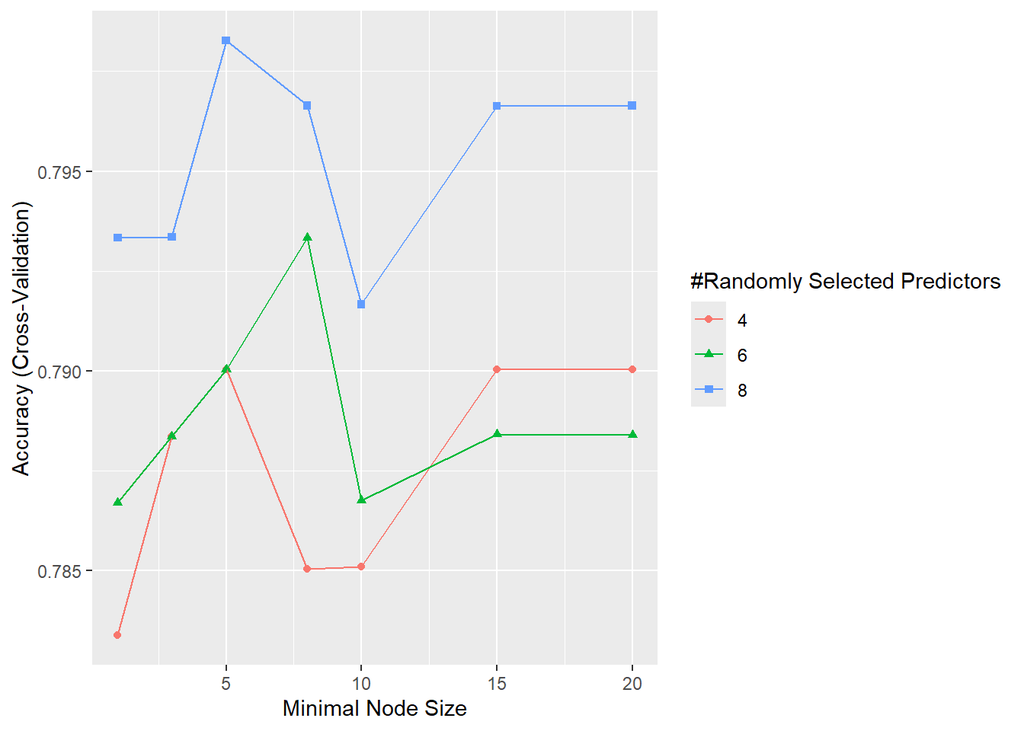

Figure 5: Visualisation of the tuning hyperparameters.

```r
ggplot(mod_cv) # visualize tuning hyperparameters results
```

The splitrule “gini” and the metric “accuracy” were used to classify the tuning parameters. The final values for the model with a number of **2000 trees** were **mtry = 8** and **min.node.size = 5**, which resulted in an **accuracy of 0.7982676**. The graph (Figure 5) shows that the differences in cross-validation accuracy between the different mtry values (4, 6, 8) are very small (they vary only slightly between about 0.785 and 0.798). (This suggests that the performance of the model is not very sensitive (no really large differences in accuracy) to the choice of the number of randomly selected predictors).

## 3.2 Evaluation on the test dataset

```r
# predictions on the test dataset
pred_class_cv <- predict(mod_cv, newdata = df_test_wl)

# make sure the variable is a factor and with correct levels (0/1)
pred_class_cv <- factor(pred_class_cv, levels = c(0, 1), labels = c("NoWaterlog", "Waterlog"))

# apply to test dataset classes
true_class_cv <- factor(df_test_wl[[target_wl]],
                        levels = c(0, 1),
                        labels = c("NoWaterlog", "Waterlog"))
```

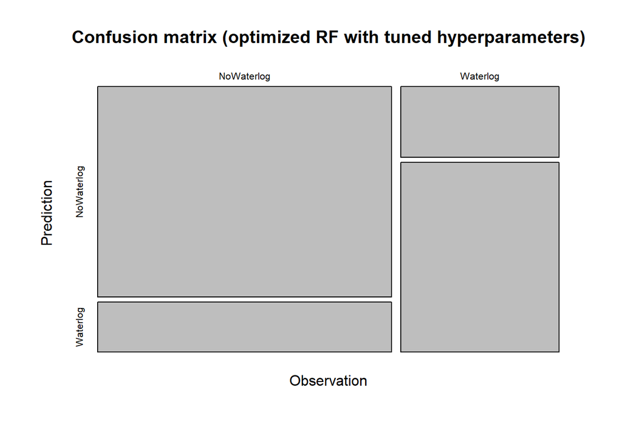

Figure 6: Confusion matrix for optimized random forest model.

```r
# confusion matrix
cm_table_cv <- table(
  Observation = true_class_cv,
  Prediction  = pred_class_cv
)

# mosaicplot
mosaicplot(cm_table_cv, main = "Confusion matrix (optimized RF with tuned hyperparameters)")
```

```r
# evaluation of the optimized model
# TP, TN, FP, FN
TP_cv <- cm_table_cv["Waterlog", "Waterlog"]
TN_cv <- cm_table_cv["NoWaterlog", "NoWaterlog"]
FP_cv <- cm_table_cv["NoWaterlog", "Waterlog"]
FN_cv <- cm_table_cv["Waterlog", "NoWaterlog"]

# accuracy, precision, true positive rate, false positve rate
accuracy_cv <- (TP_cv + TN_cv) / (TP_cv + TN_cv + FP_cv + FN_cv)
precision_cv <- TP_cv / (TP_cv + FP_cv)
tpr_cv <- TP_cv / (TP_cv + FN_cv)
fpr_cv <- FP_cv / (FP_cv + TN_cv)

# show result as table
metrics_cv <- data.frame(
  Metric = c("Accuracy", "Precision", "True positive rate", "False positive rate"),
  Value = c(round(accuracy_cv, 6),
            round(precision_cv, 6),
            round(tpr_cv, 6),
            round(fpr_cv, 6))
)

metrics_cv
```

```
##                Metric    Value
## 1            Accuracy 0.780000
## 2           Precision 0.671053
## 3  True positive rate 0.728571
## 4 False positive rate 0.192308
```

The optimized model achieved an **accuracy of 78%**, a **precision of 67%**, a **true positive rate of 73%**, and a **false positive rate of 19%**. A similar pattern can be seen in Figure 6 (confusion matrix of the optimized model), where it is clear that correctly predicted cases represent the majority.

## 3.3 Comparison initial model (basic model) vs. model with tuned hyperparameters

The R help documentation indicates that for ranger::ranger, the default hyperparameters for classification are as follows: num.trees = 500, mtry = sqrt(p) (rounded) (where p is the number of predictors), min.node.size = 1, and splitrule = gini. With these default settings, the initial base model achieved an accuracy of 76%, a precision of 65%, a true positive rate of 69%, and a false positive rate of 20%. The optimized model, in which the hyperparameters (.mtry and min.node.size) were adjusted, achieved slightly higher accuracy (78%), precision (67%), and true positive rate (73%), as well as a slightly lower false positive rate (19%). This shows that adjusting the hyperparameters resulted in a moderate improvement over the base model. Looking at the confusion matrix of the baseline model (Figure 1) and the optimized model (Figure 6), the false positive and false negative values are slightly lower in the optimized model. However, the differences are small, so no significant improvement can be seen looking at the confusion matrices alone.

*Comment on the performance of the Boruta model (without hyperparameter optimization): With 39 selected features, it performed better on the test data than the model based on the same features with optimized hyperparameters. The Boruta model achieved an accuracy of 79%, a precision of 68%, a true positive rate of 73%, and a false positive rate of 18%, while the optimized model performed slightly worse. However, the model with optimized hyperparameters showed high accuracy on the training data (0.7982676). In summary, however, the Boruta model was robust with respect to the default hyperparameters of the random forest, meaning that its predictive performance was already stable and not very sensitive to changes in mtry or min.node.size. However, there are other reasons why optimizing hyperparameters is important: it can improve model efficiency and reduce computation time by avoiding overly complex trees, and it can (not visible in my case, but in general) improve model performance when the default settings are not optimal for the specific dataset (e.g., class imbalances or overly complex data structures).*

# 4. Probabilistic predictions

## 4.1 Random forest model with optimised hyperparameters

```r
# train random forest with probability output
# using optimized hyperparameters from mod_cv
rf_bor_wl_prob <- ranger(
  y = df_train_wl[, target_wl],           # target variable
  x = df_train_wl[, predictors_all],      # predictors
  mtry = mod_cv$bestTune$mtry,
  min.node.size = mod_cv$bestTune$min.node.size,
  splitrule = "gini",
  num.trees = 500,
  probability = TRUE,
  seed = 42,
  num.threads = parallel::detectCores() - 1
)
```

```r
# predict probabilities on the test dataset
pred_prob <- predict(rf_bor_wl_prob, data = df_test_wl)$predictions

# extract probability for class = 1 = soil is waterlogged)
prob_waterlog <- pred_prob[, "1"]

# true class labels as numeric vectors (1=waterlogged soil, 0=no waterlogged soil)
true_class <- as.numeric(as.character(df_test_wl[[target_wl]]))
```

## 4.2 Reicever-operating-characteristic (ROC) curve

I used the information from the pROC package (https://search.r-project.org/CRAN/refmans/pROC/html/pROC-package.html) as well as information from other papers (see section 5) for plotting and understanding the ROC curve.

```r
# calculate ROC (receiver operating characteristic curce) & AUC (area under curve)
roc_obj <- roc(true_class, prob_waterlog)
auc_val <- auc(roc_obj)

# prepare for plotting
roc_df <- data.frame(
  FPR = 1 - roc_obj$specificities, # false positive rate
  TPR = roc_obj$sensitivities
)
```

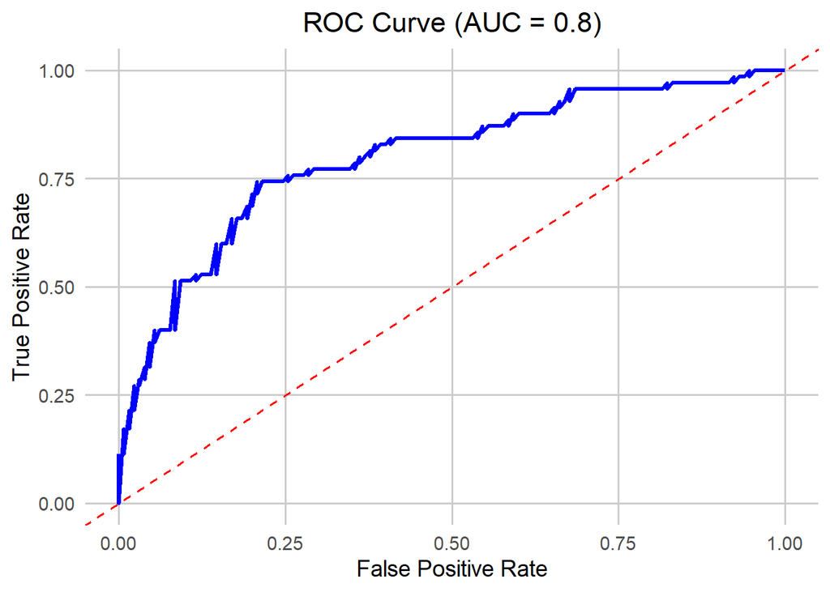

Figure 7: ROC curve.

```r
# plot ROC curve
ggplot(roc_df, aes(x = FPR, y = TPR)) +
  geom_line(color = "blue", linewidth = 1.2) +                                      # ROC line
  geom_abline(intercept = 0, slope = 1, linetype = "dashed", color = "red") +  # random classifier line
  labs(
    title = paste0("ROC Curve (AUC = ", round(auc_val, 3), ")"),
    x = "False Positive Rate",
    y = "True Positive Rate"
  ) +
  theme_minimal(base_size = 14) +
  theme(
    plot.title = element_text(hjust = 0.5),
    panel.grid.major = element_line(color = "grey80"),
    panel.grid.minor = element_blank()
  )
```

In the graph, the ROC (Receiver Operating Characteristic) curve shows the true positive rate (TPR) compared to the false positive rate (FPR) for different thresholds. The diagonal red line represents a random classifier (AUC = 0.5), while the blue line illustrates the performance of the model. The closer the blue line is to the upper left corner, the better the separation between the two classes “waterlogged/not waterlogged” (points further up the line (towards the upper left corner) mean that the model correctly identifies more waterlogged areas (higher TPR) and at the same time makes fewer errors in non-waterlogged areas (lower FPR)). The AUC value for my model is around 0.8, which indicates good discrimination between water-saturated and non-waterlogged conditions (an AUC value of 1 would mean a perfect model). The blue line also shows how TPR and FPR change across all possible thresholds. The threshold is the probability cutoff used to convert predicted probabilities into a yes/no classification. A lower threshold labels more cases as positive (captures more true positives but also more false positives), while a higher threshold is more conservative (reduces false positives but misses some true positives).

One could further plot the predictions to have a visual overview of waterlogged/no-waterlogged areas in the area of the canton of Bern (see instructions here: https://geco-bern.github.io/tutorial_digital_soil_mapping/04-model_analysis.html). As it is not absolutely needed to solve this exercise, it is not part of this markdown, but I want to highlight, that there are further possibilities to continue after having done the probabilitistic predictions.

## 4.3 Choice / Interpretation of threshold

For a project where waterlogged soils critically affect stability, a low threshold should be selected to maximize the detection of all waterlogged areas, even if this leads to an increase in false alarms. In a project where waterlogging is undesirable but not critical, a higher threshold is preferable to reduce false alarms, accepting that some waterlogged areas may be overlooked. The thresholds are different for each case because the risk tolerance is different. Another analogy can be found in medical testing: for a critical disease such as cancer, for example, a low threshold is used to avoid missed cases, while for minor illnesses (e.g., a normal mild winter cold), missing some cases is not dangerous and unnecessary interventions are avoided. This is similar to choosing a higher threshold for a non-critical waterlogging project.

# 5. References & Declaration of Authorship

I hereby declare that I (Salome Hayler) have written this report myself. It is based on basic codes and general information from the tutorial “Digital Soil Mapping – Predicting soil properties from spatial data” by Pascal Schneider, Benjamin Stocker, Madlene Nussbaum (2023) (https://geco-bern.github.io/tutorial_digital_soil_mapping/), general information from the book “Applied Geodata Science (v1.0)” by Benjamin Stocker et. al (2023), and information from lectures (given by Prof. Dr. Benjamin Stocker & Dr. Fabian Bernhard). All other sources of information are listed in this section and have been cited in the text.

AI (ChatGPT) was used to solve some technical problems regarding the code that could not be solved otherwise, including, in particular, the pROC package, which initially did not work for plotting the ROC curve (see also additional literature).

I used DeepL (free version) to check the grammatical correctness of some text passages and improve them in terms of English scientific language.

Last but not least, “R Markdown: The Definitive Guide” by Yihui Xie, J. J. Allaire, and Garrett Grolemund (2023) (available at: https://bookdown.org/yihui/rmarkdown/) served as a helpful guide to Markdown syntax.

**Data**

The report is based on the following original data from https://github.com/geco-bern/tutorial_digital_soil_mapping (in the data_raw folder), which was preprocessed prior to further analysis (see code snippet at the beginning of the script) and then stored in the data folder.

*Soil data:*

Soil observations from sampling sites in the canton of Bern, including the binary variable waterlog.100, which indicates whether soils are waterlogged at a depth of 100 cm.

*Environmental covariates:*

This dataset originally contains 99 spatial environmental covariates, which are provided as raster layers. (Full list of content here: https://geco-bern.github.io/tutorial_digital_soil_mapping/99-variables.html). After preprocessing/cleaning the original data, only 91 variables remained available for further use.

**Additional Literature**

In addition to the tutorial “Digital Soil Mapping – Predicting Soil Properties Using Spatial Data” and the AGDS book chapters on random forests, model evaluation, variable selection, classification metrics, and hyperparameter tuning, several other sources were consulted for this report.

The R documentation for the Ranger package and the pROC curve were used to gain an understanding of the implementation of random forests and ROC curves.

Two additional articles were helpful in relation to the latter: Fawcett, T. (2006). An introduction to ROC analysis. Pattern Recognition Letters, 27(8), 861-874. https://doi.org/10.1016/j.patrec.2005.10.010 . And Robin, X. et al. (2011). pROC: an open-source package for R and S+ for analyzing and comparing ROC curves. BMC Bioinformatics 12(77). https://doi.org/10.1186/1471-2105-12-77.